# Overview

This is the second portion of the project. At this part, the data that is going to be analyzed is the ToothGrowth data in the R datasets package. Project objectives include:

1. Load the ToothGrowth data and perform some basic exploratory data analyses
2. Provide a basic summary of the data.
3. Use confidence intervals and/or hypothesis tests to compare tooth growth by supp and dose. (Only use the techniques from class, even if there’s other approaches worth considering)
4. State your conclusions and the assumptions needed for your conclusions.

## Load Data

*The Effect of Vitamin C on Tooth Growth in Guinea Pigs* The response is the length of odontoblasts (teeth) in each of 10 guinea pigs at each of three dose levels of Vitamin C (0.5, 1, and 2 mg) with each of two delivery methods (orange juice or ascorbic acid, VC). A data frame with 60 observations on 3 variables: len numeric Tooth length, supp factor Supplement type (VC or OJ), and dose numeric Dose in milligrams.

**Exploratory Analysis** Analyze tooth length relative to supplement and dosage separately. From there try to answer if either dosage or supplements have effects on tooth growth.

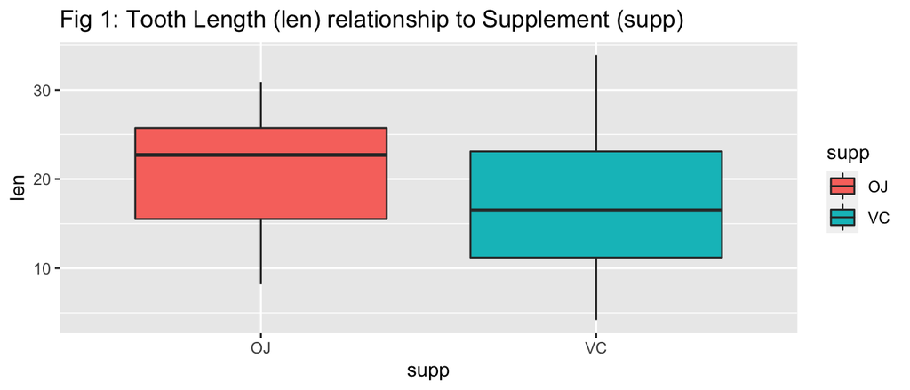

The figure above shows a box plot by supplement relative to length of tooth. Upon initial examinatiopn OJ has a better effect on teeth growth than VC. Now to determine if Dosage has an effect indepedently of supplement.

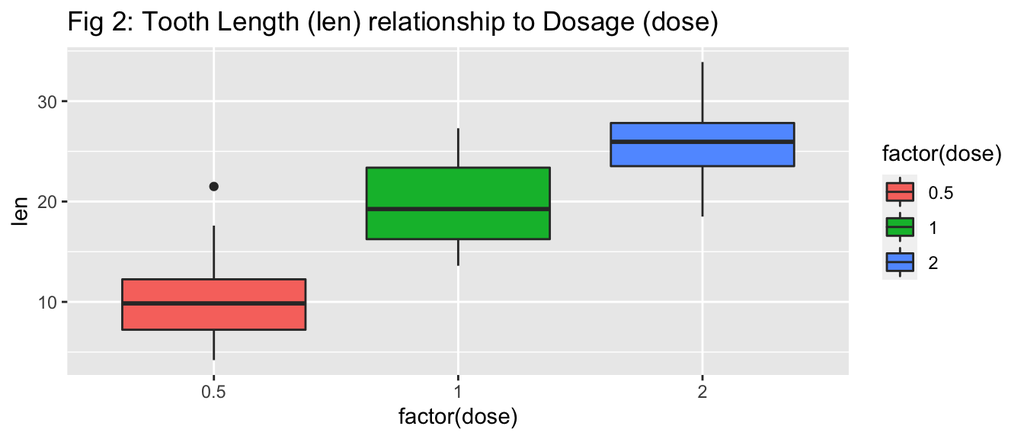

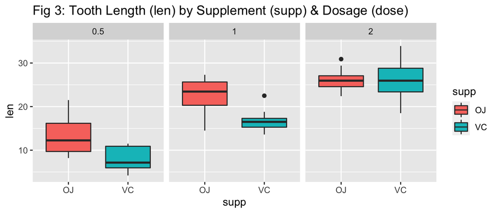

The figure above shows a box plot of the length of tooth by supplement and dosage. As dosages increase, the longer the tooth grows. The graph shows the effects of tooth growth are similar for both supplements at 2 mg. While an OJ supplemnt has a better effect on teeth growth than VC looking at the plot at a 0.5 and 1 mg dose.

**Testing using confidence interval and/or hypothesis test** Comparing tooth length by supplement using t-test

```
##
##  Welch Two Sample t-test
##
## data:  len by supp
## t = 1.9153, df = 55.309, p-value = 0.06063
## alternative hypothesis: true difference in means is not equal to 0
## 95 percent confidence interval:
##  -0.1710156  7.5710156
## sample estimates:
## mean in group OJ mean in group VC
##         20.66333         16.96333
```

The p-value is 0.06, and the confidence interval contains zero. This indicates that we can not reject the null hypothesis that the different supplement types have no effect on tooth length. Now looking at the length by dosages using a t-test.

```
##
##  Welch Two Sample t-test
##
## data:  len by dose
## t = -6.4766, df = 37.986, p-value = 1.268e-07
## alternative hypothesis: true difference in means is not equal to 0
## 95 percent confidence interval:
##  -11.983781  -6.276219
## sample estimates:
## mean in group 0.5   mean in group 1
##            10.605            19.735
```

```
##
##  Welch Two Sample t-test
##
## data:  len by dose
## t = -11.799, df = 36.883, p-value = 4.398e-14
## alternative hypothesis: true difference in means is not equal to 0
## 95 percent confidence interval:
##  -18.15617 -12.83383
## sample estimates:
## mean in group 0.5   mean in group 2
##            10.605            26.100
```

```
##
##  Welch Two Sample t-test
##
## data:  len by dose
## t = -4.9005, df = 37.101, p-value = 1.906e-05
## alternative hypothesis: true difference in means is not equal to 0
## 95 percent confidence interval:
##  -8.996481 -3.733519
## sample estimates:
## mean in group 1 mean in group 2
##          19.735          26.100
```

As can be seen, the p-value of each test was essentially zero and the confidence interval of each test does not cross over zero (0). Based on this result we can assume that the average tooth length increases with an inceasing dose, and therefore the null hypothesis can be rejected.